Année universitaire : 2025-2026

# Dynamique de confrontation :

## Modélisation statistique d’un conflit entre *Mycobacterium tuberculosis* et le système immunitaire

**Projet présenté par Mattéo Soles**

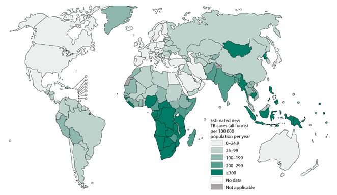

**Figure 1** : carte représentant les pays les plus touchés par la tuberculose

### **Note d’intention**

*Ce projet a été fait en autodidacte dans un but exploratoire, afin d’avoir une approche transversale de mes études en croisant mes connaissances sur la biologie moléculaire, la biologie cellulaire et la microbiologie,avec mes compétences de modélisation statistique sur l’environnement R studio. De par l’aspect autodidacte, je vais utiliser des formules mathématiques pour modeliser la dynamique des intéractions entre la bacterie et le corps et des informations vérifiées pour modéliser et rédiger cette étude, cependant ,certaines variables seront des estimations théoriques, vu que je n’ai pas fait d’expérimentation en labo pour des raisons évidentes.*

# **Introduction**

La tuberculose est une pathologie infectieuse, classée parmi les immunopathologies, connue dans le monde entier. Beaucoup la considèrent comme une maladie du passé, éradiquée au motif qu’elle est absente des médias occidentaux ; cependant, l’absence de visibilité ne signifie pas sa disparition. Des écrits mentionnant la maladie et ses symptômes datent de 3000 av. J.-C. ; l’être humain cohabite donc avec ce pathogène depuis au moins 5 000 ans. De nos jours, on estime que 25 % de la population mondiale est infectée par la bactérie responsable de la maladie : *Mycobacterium tuberculosis*. Toutefois, parmi ces 25 %, seuls 10 % développent une forme active de l’infection, les 90 % restants présentant une forme latente. On pourrait alors supposer que la mortalité est dérisoire au vu de ce faible pourcentage ; or, on dénombrait en 2024 au minimum 1,23 million de décès dus à la tuberculose dans le monde. Ce chiffre en fait la maladie infectieuse la plus meurtrière, la classant parmi les dix principales causes de mortalité à l’échelle globale. Mais face à de tels indicateurs, pourquoi une large part de l’opinion croit-elle encore à son éradication ? Essentiellement parce qu’elle a quasiment disparu des pays développés. En France, par exemple, Santé Publique France a recensé 30 décès liés à la tuberculose en 2023. Pourtant, elle sévit encore lourdement dans les pays en développement, notamment en Afrique subsaharienne, en Inde ou en Indonésie. Comme énoncé précédemment, il existe deux cas de figure chez les porteurs : la forme latente, asymptomatique et non létale, et la forme active, symptomatique et potentiellement mortelle. Plusieurs facteurs déterminent le passage à une forme active, tels que la génétique, les comorbidités, l’âge (nourrissons ou personnes âgées) ainsi que divers paramètres biologiques et environnementaux.

Tous ces facteurs convergent vers un dénominateur commun : **l’immunodéficience**. Les individus dont le système immunitaire est affaibli sont les plus susceptibles de développer la forme active. Dès 1980, des chercheurs (tels que Peter Piot et Kevin De Cock) ont observé que les patients atteints du SIDA (Syndrome d’ImmunoDéficience Acquise) présentaient un risque beaucoup plus élevé de contracter une tuberculose active. Selon l’OMS, ces patients ont également 15 à 21 fois plus de risques de succomber à la maladie qu’une personne saine. Ces recherches ont permis d’établir une corrélation directe entre tuberculose et déficit immunitaire. Bien qu’il existe plusieurs variantes de la pathologie, la forme pulmonaire demeure, de loin, la plus fréquente. Grâce aux avancées scientifiques, l’humanité a pu mettre au point des protocoles thérapeutiques à base d’antibiotiques antituberculeux, devant être suivis sur une période minimale de six mois, ainsi qu’un vaccin : le Bacille de Calmette et Guérin (BCG).

La tuberculose est une maladie induite par le bacille de Koch, mais ce n’est pas la bactérie elle-même qui cause les symptômes et la mort de l’individu. La tuberculose est ce qu’on appelle une **immunopathologie**, c’est-à-dire une maladie qui est causée par le système immunitaire, soit par une réaction immunitaire excessive (hyperinflammation) par rapport à la menace, soit par une défaillance de reconnaissance du corps (auto-immunité) et l’immunodéficience. La tuberculose est une maladie causée par une hyperinflammation. La *Mycobacterium tuberculosis* déclenche une immunopathogénèse détruisant les tissus sains.

Pour comprendre comment la bactérie agit, il faut d’abord comprendre sa structure et ses spécificités. *Mycobacterium tuberculosis* est un bacille (d’où sa deuxième appellation : Bacille de Koch) qui fait partie de la famille des mycobactéries ; c’est une bactérie pathogène primaire stricte (elle vit en contaminant des organismes) qui ne sera pas détectable après coloration de Gram à cause de ses spécificités structurelles. Le bacille de Koch fait partie d’une classe qu’on nomme Bacilles Acido-Alcoolo-Résistants (BAAR). La spécificité de ces BAAR est leur paroi qui est dure et épaisse, de par sa composition en grande quantité d’acide mycolique, qui protège la bactérie de l’environnement parfois hostile. La paroi est donc imperméable aux colorations de Gram, mais son épaisseur rend le temps de dédoublement de la bactérie très lent car il demande beaucoup d’énergie pour “casser” et reformer cette paroi. Le bacille de Koch est une bactérie au métabolisme hétérotrophe chimio-organotrophe, c’est-à-dire qu’elle a besoin de matière organique venant de son environnement (corps humain ou animal) pour s’alimenter en énergie, en électrons et en carbone. De plus, Mycobacterium tuberculosis est une bactérie aérobie stricte, elle a donc **nécessairement** besoin d’oxygène pour fonctionner.

La contamination par cette bactérie se fait par voie aérienne, rendant la transmission de la maladie très rapide. De plus, il est admis qu’une personne est infectée si l’on inhale une charge bactérienne d’environ 10 bactéries, ce qui est très peu, rendant l’épidémie très difficile à canaliser. Le mode d’action de la bactérie est complexe : une fois contaminée, la bactérie va se loger dans les poumons (tuberculose pulmonaire). Le système immunitaire inné, c’est-à-dire les cellules du système immunitaire qui sont déjà présentes sur les tissus des poumons, va réagir directement à l’arrivée de la bactérie. Les macrophages du système immunitaire vont alors capturer les bacilles de Koch, mais c’est à partir de là qu’une réaction en chaîne va se produire. La bactérie, une fois capturée par le macrophage, va détourner le macrophage, empêchant l’élimination de la bactérie, qui va alors se dédoubler grâce aux nutriments apportés par le sang de manière constante, ainsi qu’à l’oxygène des poumons qui se renouvelle sans cesse. Les conditions sont alors optimales pour la division cellulaire, bien que lente, de la bactérie. Le corps va alors réagir à la menace en formant des granulomes, qui sont des complexes créés pour enfermer le macrophage détourné et les bactéries. Le cœur du granulome est composé des bactéries en train de se dédoubler ainsi que du macrophage. Ce cœur du granulome est entouré de plusieurs couches de divers lymphocytes qui vont stopper la division des bactéries par leurs actions (sécrétions de signaux chimiques, production d’anticorps…), et enfin d’une couche solide composée de fibroblastes qui va rendre la structure totalement imperméable, empêchant l’afflux d’oxygène. La paroi fibreuse est très importante car, le bacille de Koch étant aérobie strict, elle va forcer les bactéries présentes dans le cœur à se mettre en phase latente à cause du manque d’oxygène (**hypoxie**).

**L’étude se fera autour de la problématique suivante :** Dans quelle mesure les différences de réponse immunitaire peuvent-elles être modélisées pour expliquer l’évolution de la tuberculose en l’absence de traitement, dans différentes populations ?  
On considère une non-prise en charge des infectés, donc pas de traitement pour la tuberculose en cours.

Trois hypothèses sont alors émises en conséquence de cette problématique :

- Les populations normales : on suppose qu’elles ont une tolérance et un système immunitaire moyens, elles présentent une efficacité modérée dans le contrôle de l’infection. (**population témoin**).
- Les populations vaccinées : On suppose qu’elles ont un système immunitaire efficace et rapide, permettant un meilleur contrôle de la prolifération bactérienne.
- Les populations fragiles : on suppose qu’elles présentent une tolérance faible ainsi qu’une réponse immunitaire déficiente, caractérisée par une réaction plus lente et une efficacité moindre face à l’infection.

Ce projet suivra un plan divisé en deux parties. La première partie consistera à observer l’évolution de la croissance bactérienne du bacille de Koch, et à la comparer à une bactérie plus commune pour y voir les différences. Puis la deuxième partie entrera plus dans l’observation de cette bactérie chez 3 types de populations pour voir l’impact qu’elle aura sur les différents hôtes.

## **Partie 1: croissance bactérienne du bacille de Koch**

### La croissance bactérienne

La croissance bactérienne est le phénomène désignant l’augmentation d’une population de bactérie dans un environnement en fonction du temps, c’est une information capitale pour comprendre les différences entre les bactéries car elles ont toutes des temps de croissances différents de par leurs structures, leurs spécificités métaboliques et leurs environnements (quantité de nutriment, …). La croissance bactérienne est intrinsèquement liée au temps de dédoublement de la bactérie, ce temps de dédoublement (noté D) va dépendre de la bactérie, c’est-à-dire que certaines bactéries se diviseront plus vite que d’autre. La *mycobacterium tuberculosis* (*M.tuberculosis*) à un temps de dédoublement très lent, en effet, elle se divise en 20h. Cette lenteur pour se diviser s’explique par la paroi très épaisse composée d’acide mycolique. Pour se dédoubler, le bacille de Koch va devoir “briser” cette paroi et la reformer, sauf qu’avec son aspect dur, l’énergie demandé pour faire cette réaction est énorme par rapport à une bactérie plus classique (bactérie Gram- ou bactérie Gram +). La croissance bactérienne est caractérisé par une fonction exponentielle, ça veut dire que la croissance se fait “lentement” au début, puis avec le temps, va monter de manière exponentielle.

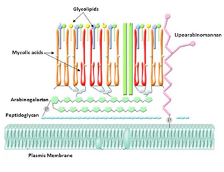

**Figure 2** : schema représentant les composants de la paroi du bacille de Koch

Afin d’illustrer cette spécificité du bacille de Koch, j’ai décidé de le comparer avec une bactérie plus commune que l’on trouve communément : *Bacillus cereus* (*B.cereus*). Le *B.cereus* est une bactérie très commune que l’on trouve dans la terre, les eaux, les végétaux et bien d’autres endroits, cette bactérie est, contrairement à *M.tuberculosis* qui est un pathogène strict primaire, une opportuniste, elle va alors profiter de brèche dans les organismes pour les contaminer, chez nous les humains, elle est l’une des principales causes d’intoxication alimentaire. La *B.cereus* est une bactérie à Gram positif qui, comparé au *M.tuberculosis* , à un temps de dédoublement de seulement 30 minutes. Cette bactérie va alors me permettre de mettre en évidence la croissance bactérienne du *M.tuberculosis* qui est spécialement lente.

La croissance bactérienne de ces deux bactéries sera modélisé en condition idéal afin de ne pas limité leurs croissances. Dans le corps humain, les nutriments et les différents besoins des bactéries sont apportées via le sang et la respiration, les conditions du corps humain sont alors bonne pour les bactéries (d’où l’existance de bactérie opportuniste ou pathogène primaire stricte qui vont vouloir, ou devront infecter les humains/animaux pour avoir accès à ces conditions de vie optimale et pouvoir alors se multiplier en masse). Le corps humain n’est cependant pas optimale à cause du système immunitaire qui joue le rôle d’agent contraignant.

### Modélisation statistique

Pour calculer la cinétique de croissance de chacune des deux bactéries, je vais utiliser la formule :  
Croissance bactérienne =

$N(t) = N_0 \cdot e^{r_{max} \cdot t}$

Où :

- $N(t)$ est l’effectif total à l’instant t
- $N_0$ est l’effectif initial
- $e$ est la constante d’Euler
- $r_{max}$ est le taux de croissance maximum ( en heure$^{-1}$)
- $t$ est le temps (en heure)

Afin de trouver $r_{max}$ nécessaire au calcul de la croissance bactérienne, je vais utiliser le temps de dédoublement. Les bactéries seront considérées comme étant constamment à leur plein potentiel au vu de leur environnement idéal :
$$r_{max} = \frac{\ln(2)}{D}$$

Où :

- $D$ est le temps de dédoublement (en heure)

Il y aura deux graphiques qui comporteront une courbe chacun : un graphique pour *B.cereus* et un graphique pour* M. tuberculosis*. Les courbes représenteront la croissance bactérienne. Je m’attends à voir une courbe en forme de “J” en ce qui concerne l’évolution de la population. C’est une forme de courbe typique des fonctions exponentielles sur une échelle classique : elle monte lentement au début, puis s’accélère très vite au fur et à mesure du temps. Cette phase de démarrage, souvent assimilée à une phase de latence, semblera beaucoup plus longue pour* M.tuberculosis* que pour *B.cereus* de par leurs taux de croissance très différents. Pour rendre visible la montée des deux courbes, l’utilisation d’échelles de temps différentes est nécessaire en raison de la grande différence de taux de croissance. Si le nombre d’heures était le même pour les deux graphiques, on ne verrait pas clairement cette forme de courbe en “J” caractéristique pour les deux bactéries.

La population initiale a été choisie comme étant $N_0 = 10$. Cela représente la charge bactérienne en *M. tuberculosis* nécessaire pour infecter un individu.

**Valeurs utilisées pour les calculs:**

- $N_0= 10$
- $t_{bc}= 7 h$
- $t_{mt}= 360h$
- $D_{bc}= 0.5h$
- $D_{mt}= 20h$

**Calcul des taux de croissance:**

*B.cereus*: $r_{max}=$ ln(2)/$D_{bc}$ = $1.386h^{-1}$

*M.tuberculosis*: $r_{max}=$ ln(2)/$D_{mt}$ = $0.0346h^{-1}$

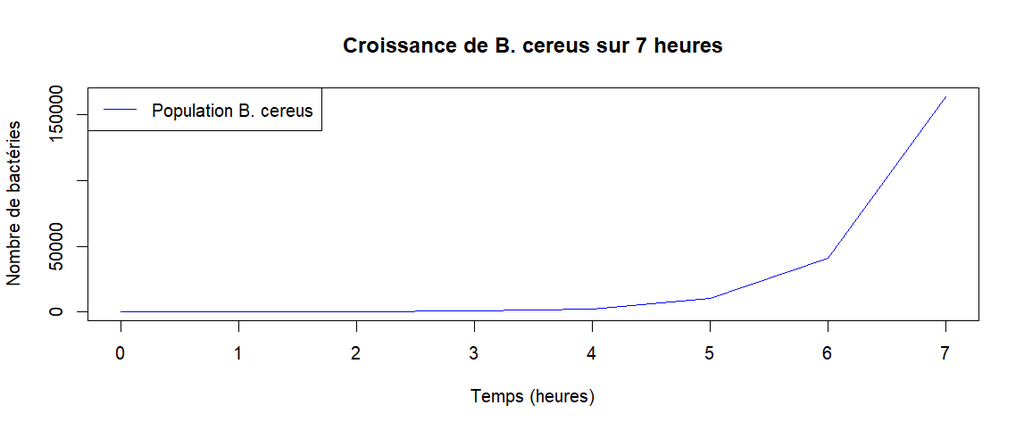

**Figure 3** : graphique de la croissance de la population bactérienne de *B.cereus* en fonction du temps (en heure)

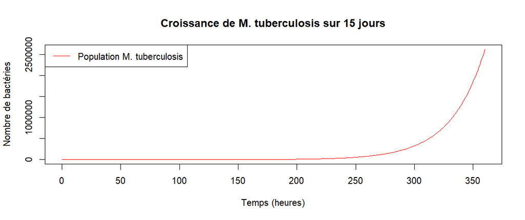

**Figure 4** : graphique de la croissance de la population bactérienne de *M.tuberculosis* en fonction du temps (en heure)

### Discussion des résultats

Dans ces deux graphiques, on voit bien représenté cette forme de courbe en J, montrant la croissance exponentielle du nombre de bactérie. Cependant, on voit aussi très bien la lenteur de croissance de *M. tuberculosis* par rapport au *B. cereus*. Cette différence est vraiment conséquente, la bacille de Koch voit une explosion dans sa croissance de population vers la 350ème heure, tandis que la *B. cereus* a cette croissance fulgurante au bout de seulement la 6ème heure. J’ai calculé à combien serait la population de cette bactérie au bout de 10 jours, afin de rapprocher le temps donné entre ces deux bactéries. Le résultat est de $3.12 * 10^{145}$, il est evidemment impossible que la bactérie atteigne un tel nombre à cause de l’espace occupée par la bactérie, le poids de toute cette population et le manque de nutriment, mais ça permet de mettre encore plus en évidence cette différence entre les deux bactéries. Ce chiffre colossal remplit son rôle de comparateur biologique : il illustre de manière frappante la dangerosité potentielle d’une croissance exponentielle sans frein immunitaire.  
Ces résultats correspondent parfaitements aux attendus, confirmant les hypothèses.

En constatant la lenteur de croissance chez *M. tuberculosis*, on comprend alors l’effet de cette paroi faite d’acide mycolique sur sa division. Donc, la vitesse de croissance bactérienne et le pouvoir pathogène de celle-ci ne sont pas forcément liés. La preuve, le *B. cereus*, qui se divise très vite, est la cause d’intoxications alimentaires, mais va dans de rares cas plus loin. Tandis que le bacille de Koch, qui se divise lentement, donne la tuberculose aux êtres vivants, causant de graves symptômes et, dans beaucoup de cas, la mort de l’hôte.

## **Partie 2 : L’impact du bacille de Koch sur les populations**

### Relation immunodéficience / Bacille de Koch

L’immunodéficience est un état physiologique amené par des maladies, la vieillesse ou des prédispositions génétiques. Être immunodéficient a pour conséquence d’avoir un système immunitaire qui est moins réactif et moins efficace. Parmi les maladies pouvant causer l’immunodéficience il y a le SIDA (Syndrome d’ImmunoDéficience Acquise), les chercheurs ont remarqué que les personnes atteintes du SIDA avaient 15 à 21 fois plus de chances de mourir de la tuberculose. Cette immunodéficience est alors un fléau qui rend la tuberculose encore plus létale qu’elle ne l’est déjà. Les personnes âgées (65-70 ans) ont aussi un système immunitaire qui devient défaillant au fil des âges, c’est un phénomène que l’on appelle : **l’immunosénescence**. Les lymphocytes T chez ces personnes, qui sont des cellules du système immunitaire qui tuent les bactéries, diminuent drastiquement. En conséquence, 21% des personnes déclarées malades de la tuberculose sont des personnes âgées. Ces personnes qui sont immunodéficientes sont alors une population dite “fragile”, de par leur susceptibilité à être infectées par les maladies, et à en développer les symptômes graves plus facilement que le reste de la population.

### Le rôle du système immunitaire

La tuberculose est une immunopathologie qui est caractérisée par sa réponse inflammatoire excessive. Cette réaction inflammatoire est causée par un glycolipide tapissant la surface de la paroi de *M. tuberculosis* : c’est le **facteur cordon**. Il provoque la panique dans le système immunitaire qui va alors recruter les cellules immunitaires en masse, pour les diriger vers les bactéries.

Le rôle du système immunitaire dans la gestion de l’infection par *M. tuberculosis* est de détruire les bactéries dès leur arrivée dans les poumons. C’est d’abord le système immunitaire inné, composé des cellules de défense déjà présentes dans les poumons (comme les macrophages alvéolaires), qui va agir en premier. Les macrophages vont alors attraper les bactéries pour les digérer. Cependant, *M. tuberculosis* empêche cette digestion et détourne le macrophage, bloquant l’apoptose (la mort cellulaire programmée) de ce dernier et altérant le bon fonctionnement de ses mitochondries. Les bactéries vont alors se multiplier, cachées dans les macrophages, en profitant de l’oxygène et des nutriments en abondance apportés par la respiration de l’hôte et les vaisseaux sanguins. Face à cette prolifération, le corps finit par s’en rendre compte et alerte de nouvelles cellules immunitaires (lymphocytes T, nouveaux macrophages, etc.), cette fois en plus grande quantité : c’est l’activation du système immunitaire adaptatif. C’est à ce moment que les macrophages infectés et les bactéries se trouvant à l’intérieur vont être encerclés pour former des granulomes quand les bactéries n’ont pas pu être détruites ( la plupart des cas). Les bactéries se retrouveront alors en hypoxie (privées d’oxygène) et entreront en phase dormante. Les cellules immunitaires et les bactéries formeront ainsi un **caséum solide**, emprisonné et contenu par le granulome. Cette réaction immunitaire est la réaction se passant chez les personnes normales. C’est-à-dire des personnes en bonne santé ne présentant pas de problème sous-jacent. Ces personnes n’auront pas ou peu de symptômes causés par la tuberculose car les bactéries sont en phase dormante et ne peuvent alors plus se multiplier. Elles sont cependant encore présentes et pourront être éliminées seulement via un long traitement à base d’antibiotiques anti-tuberculeux.

Chez les personnes atteintes d’immunodéficience (population fragile), le système immunitaire est plus lent à réagir. Cette lenteur d’action laisse le temps aux bactéries de se diviser, ce qui augmente considérablement la charge bactérienne à neutraliser avant l’arrivée du système immunitaire adaptatif.

À cette vitesse de réaction diminuée s’ajoute une efficacité globale bien moins élevée que chez les personnes saines. Lors de la tentative de formation du granulome par le système immunitaire adaptatif, le manque d’efficacité des lymphocytes T empêche de former une barrière cellulaire imperméable. Cette porosité laisse alors passer l’oxygène. Les bactéries situées au cœur du granulome ne rentrent donc pas en phase dormante et continuent à se diviser, augmentant leur nombre de façon exponentielle comme démontré précédemment. Les macrophages, qui étaient jusqu’alors maintenus en vie de force par *M. tuberculosis*, finissent par mourir de surcharge. Cette mort cellulaire, appelée **nécrose** (mort cellulaire non programmée), provoque le relâchement brutal du contenu de la cellule dans le milieu extracellulaire. Les lysosomes déversent alors leur contenu, composé de substances acides et d’enzymes destructrices (comme les protéases). De plus, les bactéries vont cataboliser les acides gras venant des membranes des cellules mortes ( bêta-oxydation), créant une acidité supplémentaire. Le cœur du granulome, composé de cellules mortes, de bactéries, d’acide et de protéases, forme ce qu’on appelle du **caséum liquide**. Cette acidité détruit les tissus pulmonaires sains, créant des trous partout dans les poumons (causant des toux sanglante). L’acidité va détruire les tissus et creuser de plus en plus ; lorsque l’érosion rencontre une bronche pulmonaire, les bactéries recevront une quantité massive d’oxygène : c’est ce qu’on appelle des **cavernes**. Les bactéries vont se multiplier de plus en plus, créant un cycle infini : plus de bactéries, création de granulomes, acidité creusant les tissus, et nouvelles bactéries par division cellulaire. C’est donc un cycle où les poumons vont subir de grandes quantités de dégâts, jusqu’à cesser de fonctionner dû aux dommages trop importants, causant la mort de l’hôte.  
Enfin, les personnes n’ont pas tous la même resistance physique face à la maladie, cette resistance influe sur la maladie est l’état de santé de l’hôte.

### Modélisation

Pour étudier l’impact de *M. tuberculosis* sur les humains, 3 populations seront étudiées pour essayer de modéliser la réalité:

- la population **normale**: réaction immunitaire moyenne en ce qui concerne la vitesse et l’efficacité. La population normal à aussi un seuil de résistance dans la moyenne. Elle constitue la population témoin du modèle.
- La population **vaccinée**: ce sont les individus ayant reçu le vaccin BCG. Ils ont une réaction immunitaire rapide et efficace. Leurs seuils de résistance sera dans la moyenne car le vaccin n’impacte pas en soi la réaction physique individuelle.
- La population **fragile**: réaction immunitaire peu efficace et un seuil de résistance faible.

Il y aura alors 3 graphiques, un par population, contenant chacun 2 courbes : la courbe représentant la croissance bactérienne et la courbe représentant l’indice inflammatoire.  
La formule pour le calcul de la croissance bactérienne de base sera la même que dans la première partie. Les données initiales seront aussi les mêmes en ce qui concerne le $r_{max}$ et la charge bactérienne initiale ($N_0$). Afin de modéliser l’impact du système immunitaire sur le développement de la bactérie, on introduit un indice inflammatoire. Le système immunitaire cherche en effet à éliminer les bactéries, mais en cas d’échec partiel, il met en place des mécanismes de confinement, notamment la formation de granulomes, afin de limiter leur prolifération. Cet indice inflammatoire, noté $p_{SI}$ allant de 0 à 1, sera représenté graphiquement par une croissance linéaire au fil du temps dès son activation. Le temps nécessaire pour passer de 0 à 1 sera différent selon l’efficacité et la réactivité du système immunitaire de chaque profil.  
Afin de modéliser le décès de l’hôte, un seuil de létalité a été mis en place. Il est lié à la tolérance physique de l’individu et correspond à une charge bactérienne critique. Si la courbe bactérienne dépasse ce seuil alors que le système immunitaire est pleinement actif ($p_{SI} = 1$), et que l’hôte reste au-dessus de ce seuil pendant 48h, on considère que les dommages tissulaires sont irréversibles. Les poumons auront subit des dégâts irreversibles, causant la mort de l’hôte. Le seuil de 48h est une valeur théorique pour mettre en place ce système de modélisation de décès, il n’y a pas de réelle preuve scientifique quand à ce chiffre.

Les seuils de létalité vont différer en fonction de la résistance de l’hôte. Ces seuils ont été choisis arbitrairement, en essayant d’être le plus biologiquement juste possible par manque de données empiriques précises.

Seuil de létalité par population :

- Population normale : charge bactérienne > $10^{13}$ bactéries
- Population vaccinée : charge bactérienne > $10^{13}$ bactéries
- Population fragile : charge bactérienne > $10^{12}$ bactéries

Ces seuils de létalité sont des valeurs théoriques pour ce modèle (paramètre heuristique), elles sont faites de sorte à suivre une logique biologique la plus proche de la réalité, mais ne sont basé sur aucune étude réelle.

Le système immunitaire va solutionner l’infection en enfermant les bactéries, les mettant alors en hypoxie. L’indice inflammatoire va donc influer sur le taux de croissance effectif. Le calcul de l’impact du système immunitaire sera alors :

$\text{Effet SI} = r_{max} \times (1 - p_{SI})$

Où:  
$p_{SI}$ est l’indice inflammatoire

Pour lier la croissance bactérienne, la formule finale sera:

$N_{t+1} = N_t \cdot e^{r_{max} \times (1 - (p_{SI_t} \times E))}$

Où:

$E$ représente l’efficacité du système immunitaire.

Cette formule permet de prendre en considération l’impact du système immunitaire. En fonction du temps de réaction du système immunitaire, $p_{SI}$ peut être à 0 puis à partir d’une heure prédeterminé en fonction de la population, il va augmenter jusqu’à 1. L’efficacité est une variable donnée qui est binaire: 1 voudra dire que le système immunitaire influe sur la croissance bactérienne, 0 voudra dire que le système immunitaire n’influe pas.  
Le temps de réaction pour l’arriver du système immunitaire adaptatif sera de :

- 21 jours pour la population normale, et prendra 7 jours pour passer de 0 à 1 en terme d’efficacité et de plein potentiel
- 3 jours pour la population vaccinée, et prendra 4 jours pour arriver à son plein fonctionnement.
- 28 jours pour la population fragile, et prendra 15 jours pour arriver de 0 à 1.

L’efficacité sera égal à 1 pour les populations normales et vaccinée. Cependant, pour le cas de l’individu fragile, le système immunitaire défaillant ne fera pas ralentir la croissance bactérienne. L’efficacité sera égal à 0 .  
Je m’attend à ce que la courbe de croissance bactérienne des populations normales et résilientes prenne une forme de J dans un premier temps avant l’action du système immunitaire ( comme dans la partie 1), puis que le système immunitaire cause une phase de ralentissement puis une phase stationnaire. Chez les personnes vaccinnées, la courbe de croissance bactérienne n’aura quasiment pas le temps de monter et l’infection sera sous contrôle très vite grâce au temps de réaction faible, le taux de croissance lent du bacille de Koch et grâce à l’efficacité élevé du système immunitaire face à cette bactérie. Enfin, la courbe de croissance bactérienne chez les populations fragiles aura la même forme que sans réponse inflammatoire, la quantité de bactérie atteindra le seuil de létalité et lorsque 48 heures seront passé au-dessus de ce seuil avec un indice inflammatoire égal à 1, la courbe s’arrêtera reflètant le décès de l’hôte.  
Pour lancer la courbe, à t= 1 heure le Nt sera l’équivalent du $N_0$ utilisé précedemment. $N_0$ valant 10 représentant la charge bactérienne minimale pour être infecter.  
Les contraintes environnementales liées aux nutriments, à l’oxygène , le problème d’espace, de déchet et de compétition interbactéries ne sont pas des variables prise en compte dans cette modélisation.  
(Je tiens à préciser que ce modèle reste une version simplifié de la réalité)  
Pour créer ces graphiques, sera mis en place une boucle codée en R. (Annexe)

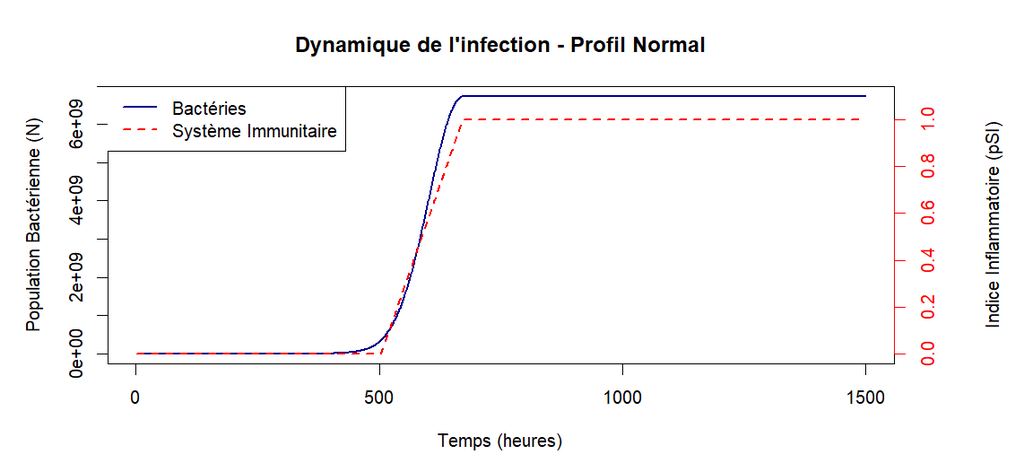

**Figure 5** : graphique représentant l’influence de l’indice inflammatoire sur la croissance bactérienne en fonction du temps chez la population noramle

- Une phase exponentielle représentant la montée maximale, entre 0 à 504 heures.
- Une phase de ralentissement où la courbe décèlére entre 504 et 672 heures.
- Une phase stationnaire où la courbe n’évolue plus à partir de 672 heures.

La phase stationnaire montre que l’infection est sous le contrôle du système immunitaire et que la population bactérienne n’évolue plus. Le seuil de létalité n’étant pas atteint, la vie de l’hôte n’est pas en danger. Mais l’hôte aura des granulômes un peu partout dans les poumons.

[figure not shown]

**Figure 6** : graphique représentant l’influence de l’indice inflammatoire sur la croissance bactérienne en fonction du temps chez la population vaccinée

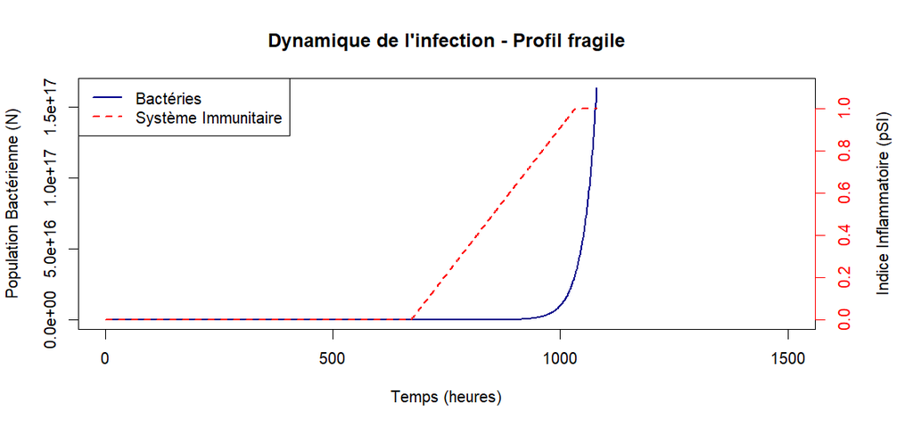

**Figure 7** : graphique représentant l’influence de l’indice inflammatoire sur la croissance bactérienne en fonction du temps chez la population fragile

On observe ici que la courbe s’arrête à une charge bactérienne de $1,6356 \times 10^{17}$ à la 1080ème heure. La charge bactérienne étant bien supérieure au seuil de létalité annoncé préalablement, le système étant arrivé à sa pleine performance a tué l’hôte en criblant ses poumons de trous, au bout de 48h avec ces deux conditions cumulées. L’efficacité étant de 0 pour la personne fragile, la courbe n’a pas connu de phase stationnaire, restant alors en phase exponentielle.  
Pour comparer les données de croissance d’une autre manière que graphiquement, le calcul de la vitesse max de croissance est un bon indicateur car il prendra tout en compte.  
Pour calculer la vitesse max, j’ai utilisé la formule de vitesse :

$v_{max}= \frac{\Delta N}{\Delta t}$

Où :

$\Delta N$ est la différence du nombre de bactéries à deux temps différents  
$\Delta t$ est la différence de temps (en heure) entre ces deux temps

La vitesse max est alors représentée par la période où la vitesse d’augmentation des bactéries est la plus élevée dans le graphique. Pour cela, j’ai demandé à R Studio de me dire à quelle heure le nombre de bactéries a augmenté le plus, et de combien. Avec ces valeurs, pour la population normale et la population vaccinée, on se rend compte que la vitesse maximale se trouve durant la phase où le système immunitaire confronte l’infection. La vitesse maximale est durant cette période car même si le taux de croissance est inhibé par l’indice inflammatoire, la population bactérienne est déjà si élevée que les multiplications se font en grand nombre, jusqu’à ce que le système immunitaire soit totalement activé (=1), où là quelle que soit la charge bactérienne plus aucune multiplication n’est possible grâce aux granulomes hermétiques. Tandis que pour la population fragile, sans influence du système immunitaire sur la croissance, le temps t choisi est le temps t juste avant la mort de l’hôte.  
Pour la population normale, cette vitesse max est de $5,8 \times 10^7$ bactéries par heure, alors que pour la population vaccinée, la vitesse max est de seulement $7,18$ bactéries par heure. Enfin, pour la population fragile, cette vitesse maximale est de $5,3 \times 10^{15}$ bactéries par heure.On voit alors la différence énorme que représente la vaccination comparée à un système immunitaire non entraîné. Le patient fragile a une vitesse maximale qui aurait pu être encore plus élevée si le patient n’était pas mort, vu que les conditions de croissance sont quasi-optimales, même si la croissance arriverait forcément à diminuer au vu de l’augmentation de demande vis-à-vis des nutriments, en lien avec l’augmentation de la population bactérienne.  
Ces résultats sont en accord avec les précédentes hypothèses, le calcul de la vitesse maximale agit comme un résultat supplémentaire validant les hypothèses émises.

### Sitographie:

- R Core Team (2026), R: A Language and Environment for Statistical Computing, R Foundation for Statistical Computing, Vienne, Autriche. Disponible sur :https://www.R-project.org/. Consulté le 15 février 2026
- AEMIP (2026), Mycobacterium tuberculosis, Association des Étudiants en Médecine et en Pharmacie, [en ligne], disponible sur :https://aemip.fr/espace-etudiants/preparation-a-linternat/mycobacterium-tuberculosis/. Consulté le 18 février 2026.
- INSERM (2024), Tuberculose, Institut National de la santé et de la recherche médicale, [en ligne],disponible sur:https://www.inserm.fr/dossier/tuberculose/. Consulté le 18 février 2026.
- WHO (2025), Tuberculose, World Health Organization, [en ligne], disponible:https://www.who.int/fr/news-room/fact-sheets/detail/tuberculosis. Consulté 18 février 2026
- Pasteur (2021),Vaccin BCG : il y a 100 ans, la première vaccination contre la tuberculose, Institut Pasteur,[en ligne], disponible sur:https://www.pasteur.fr/fr/journal-recherche/actualites/vaccin-bcg-il-y-100-ans-premiere-vaccination-contre-tuberculose. Consulté le 19 février 2026.
- AUGUSTREICH, Jacques (2020), Rôle et mécanismes moléculaires d’action des lipides de l’enveloppe de Mycobacterium tuberculosis dans la virulence, Thèse de doctorat en Biologie, Université de Toulouse, [En ligne], disponible sur :https://theses.hal.science/tel-03153676, consulté le 20 février 2026.
- KAUFMANN, Stefan (2014), La pathogenèse de la tuberculose, ResearchGate,[en ligne], disponible sur :https://www.researchgate.net/figure/La-pathogenese-de-la-tuberculose-La-transmission-de-Mtb-est-essentiellement-interhumaine_fig1_262418453, consulté le 27 février 2026.

### Support de cours:

- CLAVEL Thierry, *Microbiologie*, niveau L2, Avignon Université, année universitaire 2025-2026.
- MAZZIA Christophe, REBOUL cyril, MONNET Fabien, *biologie cellulaire*, niveau L1, Avignon Université, année universitaire 2024-2025.
- CLAVEL Thierry, CHÂTEAU Alice, *Biologie cellulaire et moléculaire*, niveau L2, Avignon université, année universitaire 2025-2026

### Crédit illustration:

# Annexe:

## Annexe 1 : Code R utilisé pour la modélisation

### Partie 1 : Croissance bactérienne (M. tuberculosis vs B. cereus)

```r
#  Paramètres initiaux
N0 <- 10
D_bc <- 0.5
D_mt <- 20

# Calcul des taux de croissance
r_bc <- log(2) / D_bc
r_mt <- log(2) / D_mt

# Vecteurs de temps
t_bc <- 0:7     # Évolution sur 7 heures pour B. cereus
t_mt <- 0:360   # Évolution sur 15 jours (360 heures) pour M. tuberculosis

#  Calcul des populations
N_bc <- N0 * exp(r_bc * t_bc)
N_mt <- N0 * exp(r_mt * t_mt)

# --- Graphiques de la Partie 1 ---

# Graphique B. cereus
plot(t_bc, N_bc, type = "l", col = "blue", lwd = 1,
     xlab = "Temps (heures)", ylab = "Nombre de bactéries",
     main = "Croissance de B. cereus sur 7 heures")
legend("topleft", legend = "Population B. cereus", col = "blue", lty = 1)

# Graphique M. tuberculosis
plot(t_mt, N_mt, type = "l", col = "red", lwd = 1,
     xlab = "Temps (heures)", ylab = "Nombre de bactéries",
     main = "Croissance de M. tuberculosis sur 15 jours")
legend("topleft", legend = "Population M. tuberculosis", col = "red", lty = 1)
```

### Partie 2: L’impact du bacille de Koch sur les populations

```r
# Population normale
nom_profil <- "Profil Normal"
N0 <- 10
r_max <- 0.0346
E <- 1
seuil_activation <- 21 * 24
temps_montee <- 7 * 24
t_max <- 1500

# 2. INITIALISATION
Nn <- numeric(t_max)
pSI <- numeric(t_max)
N[1] <- N0
pSI[1] <- 0

# 3. BOUCLE DE CALCUL
for (t in 1:(t_max - 1)) {

  # Évolution de l'indice inflammatoire pSI
  if (t >= seuil_activation) {
    pSI[t+1] <- pSI[t] + (1 / temps_montee)
    if (pSI[t+1] > 1) pSI[t+1] <- 1
  } else {
    pSI[t+1] <- pSI[t]
  }

  # Évolution Bactéries (Formule Universelle)
  N[t+1] <- N[t] * exp(r_max * (1 - (pSI[t] * E)))

}

# ==========================================================
#  GRAPHIQUE
# ==========================================================

par(mar = c(5, 5, 4, 6))

plot(1:t_max, N, type = "l", col = "darkblue", lwd = 2,
     xlab = "Temps (heures)",
     ylab = "Population Bactérienne (N)",
     main = paste("Dynamique de l'infection -", nom_profil))

par(new = TRUE)


plot(1:t_max, pSI, type = "l", col = "red", lwd = 2, lty = 2,
     axes = FALSE, xlab = "", ylab = "", ylim = c(0, 1.1))

axis(side = 4, col = "red", col.axis = "red")
mtext("Indice Inflammatoire (pSI)", side = 4, line = 4, col = "red")

legend("topleft", legend = c("Bactéries", "Système Immunitaire"),
       col = c("darkblue", "red"), lty = c(1, 2), lwd = 2, bg="white")

#Population vaccinée

nom_profil <- "Profil Vacciné"
N0 <- 10
r_max <- 0.0346
E <- 1
seuil_activation <- 3 * 24
temps_montee <- 4 * 24
t_max <- 1500

# Paramètres de létalité
seuil_letalite <- 10^13
compte_a_rebours_mort <- 0

# 2. INITIALISATION
Nv <- numeric(t_max)
pSI <- numeric(t_max)
N[1] <- N0
pSI[1] <- 0

# 3. BOUCLE DE CALCUL
for (t in 1:(t_max - 1)) {

  # Évolution de l'indice inflammatoire pSI
  if (t >= seuil_activation) {
    pSI[t+1] <- pSI[t] + (1 / temps_montee)
    if (pSI[t+1] > 1) pSI[t+1] <- 1
  } else {
    pSI[t+1] <- pSI[t]
  }

  # Évolution Bactéries (Formule Universelle)
  N[t+1] <- N[t] * exp(r_max * (1 - (pSI[t] * E)))

  # Test de létalité
  if (N[t+1] >= seuil_letalite & pSI[t+1] == 1) {

    compte_a_rebours_mort <- compte_a_rebours_mort + 1

    if (compte_a_rebours_mort >= 48) {
      print(paste("L'hôte est décédé à l'heure", t+1))

      # On remplace les zéros restants par du "vide" (NA) pour que la ligne s'arrête
      if ((t + 2) <= t_max) {
        N[(t+2):t_max] <- NA
        pSI[(t+2):t_max] <- NA
      }

      break
    }

  } else {
    compte_a_rebours_mort <- 0
  }
}
# ==========================================================
#  GRAPHIQUE
# ==========================================================

par(mar = c(5, 5, 4, 6))


plot(1:t_max, N, type = "l", col = "darkblue", lwd = 2,
     xlab = "Temps (heures)",
     ylab = "Population Bactérienne (N)",
     main = paste("Dynamique de l'infection -", nom_profil))

par(new = TRUE)


plot(1:t_max, pSI, type = "l", col = "red", lwd = 2, lty = 2,
     axes = FALSE, xlab = "", ylab = "", ylim = c(0, 1.1))

axis(side = 4, col = "red", col.axis = "red")
mtext("Indice Inflammatoire (pSI)", side = 4, line = 4, col = "red")

legend("topleft", legend = c("Bactéries", "Système Immunitaire"),
       col = c("darkblue", "red"), lty = c(1, 2), lwd = 2, bg="white")

#Population fragile

nom_profil <- "Profil Fragile"
N0 <- 10
r_max <- 0.0346
E <- 0
seuil_activation <- 28 * 24
temps_montee <- 15 * 24
t_max <- 1500

# Paramètres de létalité spécifiques au profil fragile
seuil_letalite_fragile <- 10^12
compte_a_rebours_mort <- 0

# 2. INITIALISATION
Nf <- numeric(t_max)
pSI <- numeric(t_max)
N[1] <- N0
pSI[1] <- 0

# 3. BOUCLE DE CALCUL
for (t in 1:(t_max - 1)) {

  if (t >= seuil_activation) {
    pSI[t+1] <- pSI[t] + (1 / temps_montee)
    if (pSI[t+1] > 1) pSI[t+1] <- 1
  } else {
    pSI[t+1] <- pSI[t]
  }

  N[t+1] <- N[t] * exp(r_max * (1 - (pSI[t] * E)))

  # Test de létalité pour le patient fragile
  if (N[t+1] >= seuil_letalite_fragile & pSI[t+1] == 1) {

    compte_a_rebours_mort <- compte_a_rebours_mort + 1

    if (compte_a_rebours_mort >= 48) {

      print(paste("L'hôte est décédé à l'heure", t+1))


      if ((t + 2) <= t_max) {
        N[(t+2):t_max] <- NA
        pSI[(t+2):t_max] <- NA
      }

      break
    }

  } else {
    compte_a_rebours_mort <- 0
  }
}

# ==========================================================
# 4. GRAPHIQUE
# ==========================================================

par(mar = c(5, 5, 4, 6))


plot(1:t_max, N, type = "l", col = "darkblue", lwd = 2,
     xlab = "Temps (heures)",
     ylab = "Population Bactérienne (N)",
     main = paste("Dynamique de l'infection -", nom_profil))

par(new = TRUE)


plot(1:t_max, pSI, type = "l", col = "red", lwd = 2, lty = 2,
     axes = FALSE, xlab = "", ylab = "", ylim = c(0, 1.1))

axis(side = 4, col = "red", col.axis = "red")
mtext("Indice Inflammatoire (pSI)", side = 4, line = 4, col = "red")

legend("topleft", legend = c("Bactéries", "Système Immunitaire"),
       col = c("darkblue", "red"), lty = c(1, 2), lwd = 2, bg="white")

#=============================================================================
# Calcul de Vmax
#=============================================================================

# Normal

vitesse_normal= diff(N)
max(vitesse_normal, na.rm=TRUE)
which.max(vitesse_normal)
vmax_n=(N[602]-N[601])/(602-601)

vmax_n #=58574226 bactéries par heure

# vaccinée
vitesse_vacciné= diff(N)
max(vitesse_vacciné, na.rm=TRUE)
which.max(vitesse_vacciné)
vmax_v=(N[115]-N[114])/(115-114)

vmax_v #= 7.188 bactéries/heure

# Fragile

vitesse_fragile= diff(N)
max(vitesse_fragile, na.rm=TRUE)
which.max(vitesse_fragile)
vmax_f= (N[1079]-N[1078])/(1079-1078)

vmax_f #=5.373379e+15 bactérie par heure
```